# Régression Multiple - Validation

Paul Bastide

2025-11-28

# Model Validation

## Gaussian Model

### Model:

$$\mathbf{y} = \mathbf{X}\boldsymbol{\beta} + \boldsymbol{\epsilon}$$

- $\mathbf{y}$ **random** vector of $n$ responses
- $\mathbf{X}$ **non random** $n\times p$ matrix of predictors
- $\boldsymbol{\epsilon}$ **random** vector of $n$ errors
- $\boldsymbol{\beta}$ **non random, unknown** vector of $p$ coefficients

### Assumptions:

- (H1) $rg(\mathbf{X}) = p$
- (H2) $\boldsymbol{\epsilon} \sim \mathcal{N}(\mathbf{0}, \sigma^2 \mathbf{I}_n)$

## Advertising Data

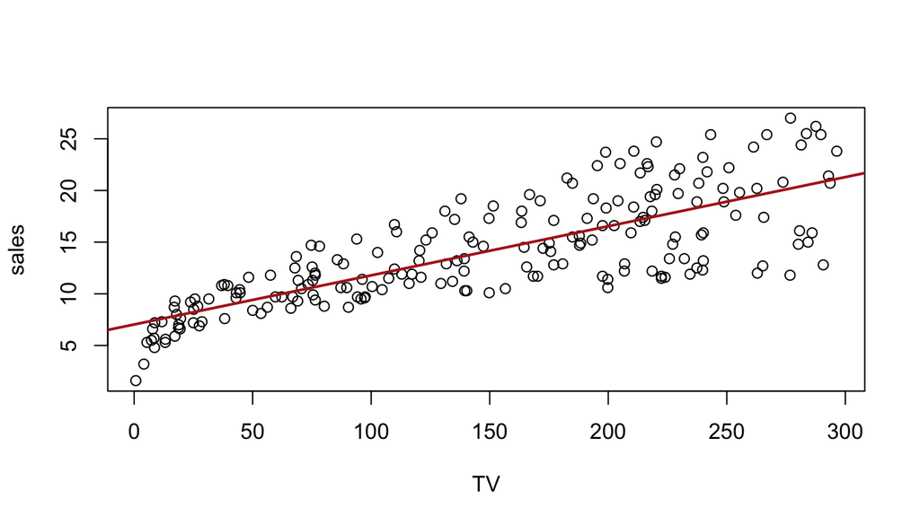

**Question**:  
Are the residuals independent, identically distributed, with the same variance $\sigma^2$ ?

## Validation

- **Goal**: Test hypothesis (H2): $\boldsymbol{\epsilon} \sim \mathcal{N}(\mathbf{0}, \sigma^2 \mathbf{I}_n)$.
- **Check residuals**:
  - Are there outliers ?
  - Gaussian assumption ?
  - Homoscedasticity ?
  - Structure ?
- **Check fit**:
  - Leverage
  - Cook distance

# Studentized Residuals

## Errors vs Residuals

From (H2), the **errors are iid**:
$$\epsilon_i \sim \mathcal{N}(0, \sigma^2 )$$

The **residuals** have distribution:
$$\hat{\boldsymbol{\epsilon}}
= \mathbf{y} - \hat{\mathbf{y}}
= (\mathbf{I}_n - \mathbf{P}^{\mathbf{X}})\mathbf{y}
\sim \mathcal{N}(\mathbf{0}, \sigma^2 (\mathbf{I}_n - \mathbf{P}^{\mathbf{X}}))$$

Writing:
$$\mathbf{H}
= \mathbf{P}^{\mathbf{X}}
= \mathbf{X}(\mathbf{X}^{T}\mathbf{X})^{-1}\mathbf{X}^{T}$$

The **residuals** have distribution:
$$\hat{\epsilon}_i
\sim \mathcal{N}(0, \sigma^2 (1 - h_{ii}))$$

## Errors vs Residuals

From (H2), the **errors are iid**:
$$\epsilon_i \sim \mathcal{N}(0, \sigma^2 )$$
But the **residuals** variance depends on $i$:
$$\hat{\epsilon}_i
\sim \mathcal{N}(0, \sigma^2 (1 - h_{ii})).$$

**“Studentization”**: try to “uniformize” the residuals so that they are iid.

## Normalisation

Normalized residuals:
$$\frac{\hat{\epsilon}_i}{\sqrt{\sigma^2 (1 - h_{ii})}}
\sim \mathcal{N}(0, 1).$$

Normalized residuals are iid.

**Problem**: $\sigma^2$ is unknown $\to$ replace it by $\hat{\sigma}^2$.

## Standardized residuals

What is the distribution of
$$t_i = \frac{\hat{\epsilon}_i}{\sqrt{\hat{\sigma}^2 (1 - h_{ii})}}
\sim
~?$$

If $\hat{\sigma}^2 = \frac{1}{n - p} \| \hat{\epsilon} \|^2$ is the standard unbiaised variance estimate, the $t_i$ **are not Student** (!)

That is because $\hat{\sigma}^2$ is **not independent** from $\hat{\epsilon}_i$ in general.

**Solution**: Replace $\hat{\sigma}^2$ with $\hat{\sigma}^2_{(-i)}$ an estimate of $\sigma^2$ independent of $\hat{\epsilon}_i$.

## Cross Validation

**Leave-one-out** cross validation: for all $i$:

1. Remove observation $i$ from the dataset:
   $$\mathbf{y}_{(-i)}
   = \begin{pmatrix}
   y_1\\
   \vdots\\
   y_{i-1}\\
   y_{i+1}\\
   \vdots\\
   y_n
   \end{pmatrix}
   \qquad\qquad
   \mathbf{X}_{(-i)}
   = \begin{pmatrix}
   \mathbf{x}^1\\
   \vdots\\
   \mathbf{x}^{i-1}\\
   \mathbf{x}^{i+1}\\
   \vdots\\
   \mathbf{x}^{n}
   \end{pmatrix}$$
2. Fit the dataset *without observation $i$*:
   - Get $\hat{\boldsymbol{\beta}}_{(-i)}$ and $\hat{\sigma}^2_{(-i)}$ using $\mathbf{y}_{(-i)}$ and $\mathbf{X}_{(-i)}$.
3. Predict point $i$ using fitted values:
   - $\hat{y}_i^P = \mathbf{x}^i\hat{\boldsymbol{\beta}}_{(-i)}$

## Cross Validation

Then, from CM4, we get:
$$\frac{y_{i} - \hat{y}_{i}^P}
{\sqrt{\hat{\sigma}^2_{(-i)} \left(1 +
\mathbf{x}^{i} (\mathbf{X}_{(-i)}^T\mathbf{X}_{(-i)})^{-1}(\mathbf{x}^{i})^T
\right)}}
\sim
\mathcal{T}_{n - p -1}$$

The **prediction error** from the leave-one-out cross validation follows a Student with $n-p-1$ degrees of freedom.

## Studentized Residuals

If $\mathbf{X}$ and $\mathbf{X}_{(-i)}$ all have rank $p$, then:

$$t_i^*
= \frac{\hat{\epsilon}_i}{\sqrt{\hat{\sigma}^2_{(-i)} (1 - h_{ii})}}
= \frac{y_{i} - \hat{y}_{i}^P}
{\sqrt{\hat{\sigma}^2_{(-i)} \left(1 +
\mathbf{x}^{i} (\mathbf{X}_{(-i)}^T\mathbf{X}_{(-i)})^{-1}(\mathbf{x}^{i})^T
\right)}}$$

and:
$$t_i^*
\sim
\mathcal{T}_{n - p -1}.$$

The **studentized residuals** are equal to  
the **normalized predictions** from the leave-one-out cross validation.

## Sherman–Morrison formula

**Sherman–Morrison formula** (also “Woodbury formula”):
For any invertible square $q \times q$ matrix $\mathbf{A}$ and vectors $\mathbf{u}$ and $\mathbf{v}$ of $\mathbb{R}^q$, then $\mathbf{A} + \mathbf{u}\mathbf{v}^T$ is invertible iff $1 + \mathbf{v}^T\mathbf{A}^{-1}\mathbf{u} \neq 0$, and:
$$(\mathbf{A} + \mathbf{u}\mathbf{v}^T)^{-1}
=
\mathbf{A}^{-1}
-
\frac{
\mathbf{A}^{-1} \mathbf{u}\mathbf{v}^T \mathbf{A}^{-1}
}{
1 + \mathbf{v}^T\mathbf{A}^{-1}\mathbf{u}
}.$$
$~$

**Proof**: exercise ([wikipedia](https://en.wikipedia.org/wiki/Sherman%E2%80%93Morrison_formula) is a great resource).

## Studentized Residuals - Proof

$$t_i^*
= \frac{\hat{\epsilon}_i}{\sqrt{\hat{\sigma}^2_{(-i)} (1 - h_{ii})}}
= \frac{y_{i} - \hat{y}_{i}^P}
{\sqrt{\hat{\sigma}^2_{(-i)} \left(1 +
\mathbf{x}^{i} (\mathbf{X}_{(-i)}^T\mathbf{X}_{(-i)})^{-1}(\mathbf{x}^{i})^T
\right)}}$$

**Hints**:

$$(\mathbf{A} + \mathbf{u}\mathbf{v}^T)^{-1}
=
\mathbf{A}^{-1}
-
\frac{
\mathbf{A}^{-1} \mathbf{u}\mathbf{v}^T \mathbf{A}^{-1}
}{
1 + \mathbf{v}^T\mathbf{A}^{-1}\mathbf{u}
}.$$

$$\mathbf{X}^T\mathbf{X}
= \mathbf{X}_{(-i)}^T\mathbf{X}_{(-i)} + (\mathbf{x}^{i})^T\mathbf{x}^i$$

$$\mathbf{X}^T\mathbf{y}
= \mathbf{X}_{(-i)}^T\mathbf{y}_{(-i)} + (\mathbf{x}^{i})^Ty_i$$

$$h_{ii}
=
[\mathbf{X}(\mathbf{X}^{T}\mathbf{X})^{-1}\mathbf{X}^{T}]_{ii}
= \mathbf{x}^{i} (\mathbf{X}^T\mathbf{X})^{-1} (\mathbf{x}^{i})^T$$

So:
$$(\mathbf{X}_{(-i)}^T\mathbf{X}_{(-i)})^{-1}
= (\mathbf{X}^T\mathbf{X} - (\mathbf{x}^{i})^T\mathbf{x}^i)^{-1}
= \cdots$$

$$\hat{y}_i^P
= \mathbf{x}^i\hat{\boldsymbol{\beta}}_{(-i)}
= \mathbf{x}^i(\mathbf{X}_{(-i)}^T\mathbf{X}_{(-i)})^{-1}\mathbf{X}_{(-i)}^T\mathbf{y}_{(-i)}
= \cdots$$

## Studentized Residuals - Proof - 1/6

$$(\mathbf{X}_{(-i)}^T\mathbf{X}_{(-i)})^{-1}
= (\mathbf{X}^T\mathbf{X} - (\mathbf{x}^{i})^T\mathbf{x}^i)^{-1}
= \cdots$$

$$(\mathbf{X}_{(-i)}^T\mathbf{X}_{(-i)})^{-1}
= (\mathbf{X}^T\mathbf{X})^{-1}
+
\frac{
(\mathbf{X}^T\mathbf{X})^{-1} (\mathbf{x}^{i})^T\mathbf{x}^{i} (\mathbf{X}^T\mathbf{X})^{-1}
}{
1 - \mathbf{x}^{i}(\mathbf{X}^T\mathbf{X})^{-1}(\mathbf{x}^{i})^T
}$$

$$(\mathbf{X}_{(-i)}^T\mathbf{X}_{(-i)})^{-1}
= (\mathbf{X}^T\mathbf{X})^{-1} + \frac{(\mathbf{X}^T\mathbf{X})^{-1} (\mathbf{x}^{i})^T\mathbf{x}^{i} (\mathbf{X}^T\mathbf{X})^{-1}}{1 - h_{ii}}$$

Hence:
$$1 + \mathbf{x}^{i}(\mathbf{X}_{(-i)}^T\mathbf{X}_{(-i)})^{-1}(\mathbf{x}^{i})^T
= 1 + h_{ii} +\frac{h_{ii}^2}{1 - h_{ii}}
= \frac{1}{1 - h_{ii}}$$

## Studentized Residuals - Proof - 2/6

$$\hat{y}_i^P
= \mathbf{x}^i\hat{\boldsymbol{\beta}}_{(-i)}
= \mathbf{x}^i(\mathbf{X}_{(-i)}^T\mathbf{X}_{(-i)})^{-1}\mathbf{X}_{(-i)}^T\mathbf{y}_{(-i)}$$

But:
$$(\mathbf{X}_{(-i)}^T\mathbf{X}_{(-i)})^{-1}
=
(\mathbf{X}^T\mathbf{X})^{-1} +
\frac{(\mathbf{X}^T\mathbf{X})^{-1} (\mathbf{x}^{i})^T\mathbf{x}^{i} (\mathbf{X}^T\mathbf{X})^{-1}}{1 - h_{ii}}$$
$$\mathbf{X}_{(-i)}^T\mathbf{y}_{(-i)}
=
\mathbf{X}^T\mathbf{y} - (\mathbf{x}^{i})^Ty_i$$

Hence:
$$\begin{multline}
\hat{y}_i^P
= \mathbf{x}^i\left[
(\mathbf{X}^T\mathbf{X})^{-1} + \frac{(\mathbf{X}^T\mathbf{X})^{-1} (\mathbf{x}^{i})^T\mathbf{x}^{i} (\mathbf{X}^T\mathbf{X})^{-1}}{1 - h_{ii}}
\right]
\\
\times
[\mathbf{X}^T\mathbf{y} - (\mathbf{x}^{i})^Ty_i]
\end{multline}$$

## Studentized Residuals - Proof - 3/6

$$\begin{multline}
\hat{y}_i^P
= \mathbf{x}^i (\mathbf{X}^T\mathbf{X})^{-1} \mathbf{X}^T\mathbf{y}
- \mathbf{x}^i (\mathbf{X}^T\mathbf{X})^{-1} (\mathbf{x}^{i})^Ty_i
\\
+ \frac{\mathbf{x}^i(\mathbf{X}^T\mathbf{X})^{-1} (\mathbf{x}^{i})^T}{1 - h_{ii}}\mathbf{x}^{i} (\mathbf{X}^T\mathbf{X})^{-1} \mathbf{X}^T\mathbf{y}
\\
- \frac{\mathbf{x}^i(\mathbf{X}^T\mathbf{X})^{-1} (\mathbf{x}^{i})^T\mathbf{x}^{i} (\mathbf{X}^T\mathbf{X})^{-1}(\mathbf{x}^{i})^T}{1 - h_{ii}} y_i
\end{multline}$$

$$\hat{y}_i^P
= \mathbf{x}^i \hat{\boldsymbol{\beta}}
- h_{ii}y_i
+ \frac{h_{ii}}{1-h_{ii}}\mathbf{x}^i \hat{\boldsymbol{\beta}}
- \frac{h_{ii}^2}{1-h_{ii}} y_i$$

$$\hat{y}_i^P
= \left(1 + \frac{h_{ii}}{1-h_{ii}}\right) \hat{y}_i
- \left(h_{ii} + \frac{h_{ii}^2}{1-h_{ii}}\right) y_i$$

## Studentized Residuals - Proof - 4/6

$$\hat{y}_i^P
= \frac{1}{1-h_{ii}}\hat{y}_i - \frac{h_{ii}}{1-h_{ii}} y_i$$

So:
$$y_i - \hat{y}_i^P
= - \frac{1}{1-h_{ii}}\hat{y}_i + \left(1 + \frac{h_{ii}}{1-h_{ii}}\right) y_i$$

And:
$$y_i - \hat{y}_i^P
= \frac{1}{1-h_{ii}}(y_i - \hat{y}_i)
= \frac{1}{1-h_{ii}}\hat{\epsilon}_i$$

## Studentized Residuals - Proof - 5/6

We have:
$$1 + \mathbf{x}^{i}(\mathbf{X}_{(-i)}^T\mathbf{X}_{(-i)})^{-1}(\mathbf{x}^{i})^T
= \frac{1}{1 - h_{ii}}$$
$$y_i - \hat{y}_i^P
= \frac{1}{1-h_{ii}}\hat{\epsilon}_i$$

Hence:
$$\begin{aligned}
t_i^*
&= \frac{y_{i} - \hat{y}_{i}^P}
{\sqrt{\hat{\sigma}^2_{(-i)} \left(1 +
\mathbf{x}^{i} (\mathbf{X}_{(-i)}^T\mathbf{X}_{(-i)})^{-1}(\mathbf{x}^{i})^T
\right)}}\\
&= \frac{\hat{\epsilon}_i/(1-h_{ii})}{\sqrt{\hat{\sigma}^2_{(-i)} /(1-h_{ii})}} \\
\end{aligned}$$

## Studentized Residuals - Proof - 6/6

Hence:
$$\begin{aligned}
t_i^*
&= \frac{y_{i} - \hat{y}_{i}^P}
{\sqrt{\hat{\sigma}^2_{(-i)} \left(1 +
\mathbf{x}^{i} (\mathbf{X}_{(-i)}^T\mathbf{X}_{(-i)})^{-1}(\mathbf{x}^{i})^T
\right)}}\\
&= \frac{\hat{\epsilon}_i}{\sqrt{\hat{\sigma}^2_{(-i)} (1 - h_{ii})}} \\
&\sim \mathcal{T}_{n - p -1}.
\end{aligned}$$

## Standardized vs Studentized Residuals

**Studentized Residuals**: Student iid
$$t_i^*
= \frac{\hat{\epsilon}_i}{\sqrt{\hat{\sigma}^2_{(-i)} (1 - h_{ii})}}
\sim \mathcal{T}_{n - p -1}.$$

Also called “externally studentized residuals”, “deleted residuals”, “jackknifed residuals”, “leave-one-out residuals”. Function `rstudent`.

**Standardized Residuals**: *not* Student in general
$$t_i = \frac{\hat{\epsilon}_i}{\sqrt{\hat{\sigma}^2 (1 - h_{ii})}}$$

Also called “internally studentized residuals” (although they are **not** Student). Function `rstandard`.

## Standardized vs Studentized Residuals

It can be shown that:
$$t_i^*
= t_i \sqrt{\frac{n-p-1}{n-p-t_i^2}}$$

So that the Studentized residuals are cheap to compute.

# Outliers

## Studentized Residuals

Studentized Residuals
$$t_i^*
= \frac{\hat{\epsilon}_i}{\sqrt{\hat{\sigma}^2_{(-i)} (1 - h_{ii})}}
\sim \mathcal{T}_{n - p -1}.$$

With probability $1 - \alpha$:
$$|t_i^*| \leq t_{n-p-1}(1-\alpha/2) \quad \forall i$$

**Note**: if $n$ is large and $\alpha=0.05$, $t_{n-p-1}(1-\alpha/2) \approx 1.96$.

## Simulation

```r
set.seed(1289)

## Predictors
n <- 500
x_1 <- runif(n, min = -2, max = 2)
x_2 <- runif(n, min = -2, max = 2)

## Model
beta_0 <- -1; beta_1 <- 3; beta_2 <- -1

## sim
eps <- rnorm(n, mean = 0, sd = 2)
y_sim <- beta_0 + beta_1 * x_1 + beta_2 * x_2 + eps

## Fit
p <- 3
fit <- lm(y_sim ~ x_1 + x_2)
```

## Simulation

```r
## 5% threshold
alp <- 0.05
t_student <- qt(1 - alp/2, n-p-1)

## Studentized residuals
res_student <- rstudent(fit)

## How many above the threshold ?
mean(abs(res_student) >= t_student)
```

```
[1] 0.046
```

## Simulation

```r
## Plot
plot(res_student)
lines(rep(t_student, n), col = "firebrick", lwd = 2)
lines(rep(-t_student, n), col = "firebrick", lwd = 2)
```

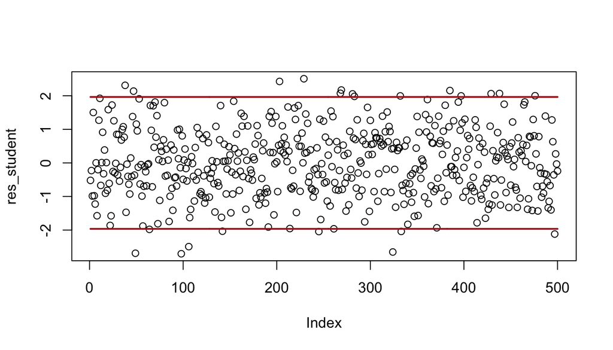

## Outliers

An **Outlier** is a point such that
$$t_i^* \gg t_{n-p-1}(1-\alpha/2)$$

i.e. a point that we do not believe was issued from a Student distribution.

“Very much higher” does not have a formal definition…

## Simulation - Outlier

```r
## Generate an outlier
y_sim[100] <- 1.3 * max(y_sim)

## Fit
fit <- lm(y_sim ~ x_1 + x_2)
```

## Simulation - Outlier

```r
## Plot
plot(rstudent(fit))
lines(rep(t_student, n), col = "firebrick", lwd = 2)
lines(rep(-t_student, n), col = "firebrick", lwd = 2)
```

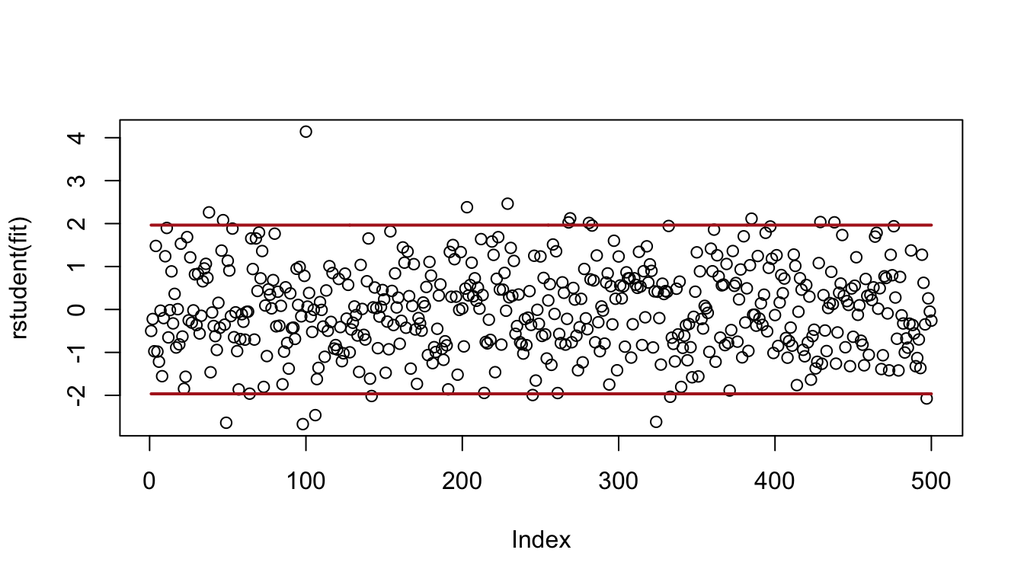

# Gaussian Hypothesis

## Studentized Residuals

Studentized Residuals
$$t_i^*
= \frac{\hat{\epsilon}_i}{\sqrt{\hat{\sigma}^2_{(-i)} (1 - h_{ii})}}
\sim \mathcal{T}_{n - p -1}.$$

If $n$ is large, then $\mathcal{T}_{n - p -1} \approx \mathcal{N}(0,1)$.

$\to$ QQ-plot on the Studentized residuals.

## Simulation - Gaussian

```r
## Gaussian sim
eps <- rnorm(n, mean = 0, sd = 2)

## QQ norm
qqnorm(eps)
qqline(eps, col = "lightblue", lwd = 2)
```

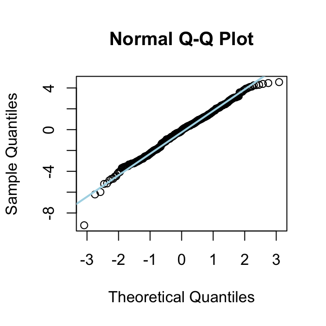

## Simulation - Gaussian

```r
## Sim
y_sim <- beta_0 + beta_1 * x_1 + beta_2 * x_2 + eps
## Fit
fit <- lm(y_sim ~ x_1 + x_2)
## Studentized residuals
qqnorm(rstudent(fit)); qqline(rstudent(fit), col = "lightblue", lwd = 2)
```

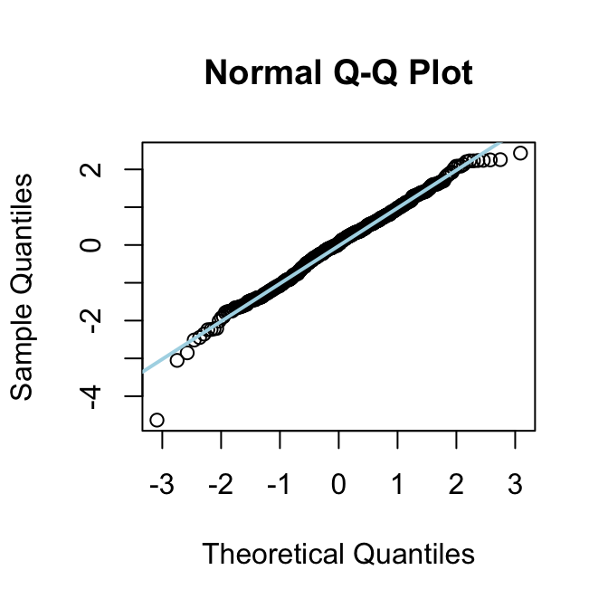

## Simulation - Not Gaussian

```r
## Student sim
eps <- rt(n, 3)

## QQ norm
qqnorm(eps)
qqline(eps, col = "lightblue", lwd = 2)
```

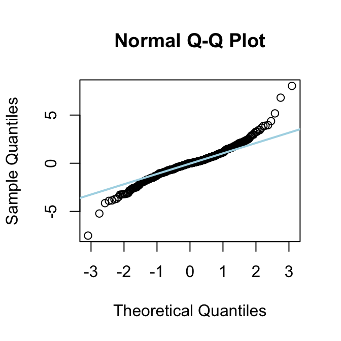

## Simulation - Not Gaussian

```r
## Sim
y_sim <- beta_0 + beta_1 * x_1 + beta_2 * x_2 + eps
## Fit
fit <- lm(y_sim ~ x_1 + x_2)
## Studentized residuals
qqnorm(rstudent(fit)); qqline(rstudent(fit), col = "lightblue", lwd = 2)
```

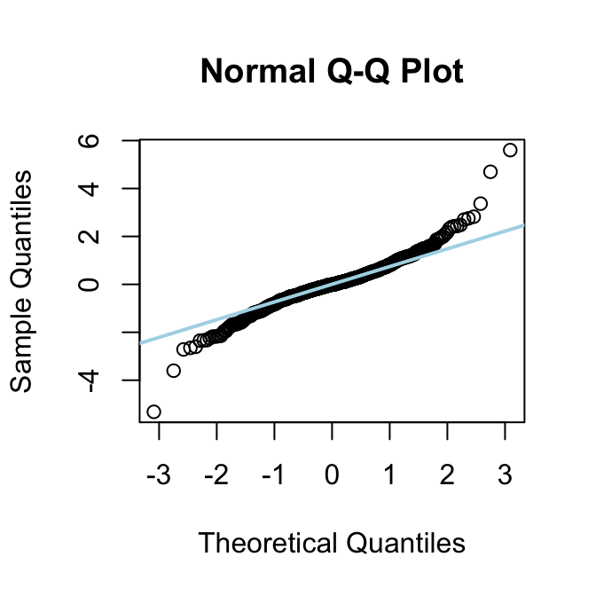

## Non Gaussian case - Coefficients

What about the distribution of $\hat{\beta}_2$ ?

If $\epsilon_i \sim \mathcal{N}(0, \sigma^2 )$ iid, then
$$\hat{\beta}_2 \sim \mathcal{N}(\beta_2, \sigma^2 [(\mathbf{X}^T\mathbf{X})^{-1}]_{22})$$

If the $\epsilon_i$ are not Gaussian, this is **not true** anymore.

Is it *approximatelly* true ?

## Simulation - Gaussian

What about the distribution of $\hat{\beta}_2$ ?

```r
set.seed(1289)
Nsim <- 1000
beta_hat_2 <- vector("numeric", Nsim)
for (i in 1:Nsim) {
  ## error
  eps <- rnorm(n, 0, 1)
  ## Sim
  y_sim <- beta_0 + beta_1 * x_1 + beta_2 * x_2 + eps
  ## Fit
  fit <- lm(y_sim ~ x_1 + x_2)
  ## Get beta_2
  beta_hat_2[i] <- coef(fit)[3]
}
```

## Simulation - Gaussian

What about the distribution of $\hat{\beta}_2$ ?

```r
## Empirical distribution
qqnorm(beta_hat_2); qqline(beta_hat_2, col = "lightblue", lwd = 2)
```

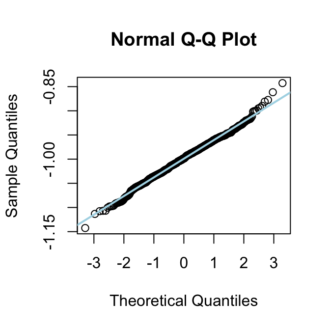

## Simulation - Not Gaussian

What about the distribution of $\hat{\beta}_2$ ?

```r
set.seed(1289)
Nsim <- 1000
beta_hat_2 <- vector("numeric", Nsim)
for (i in 1:Nsim) {
  ## error
  eps <- rt(n, 3)
  ## Sim
  y_sim <- beta_0 + beta_1 * x_1 + beta_2 * x_2 + eps
  ## Fit
  fit <- lm(y_sim ~ x_1 + x_2)
  ## Get beta_2
  beta_hat_2[i] <- coef(fit)[3]
}
```

## Simulation - Not Gaussian

What about the distribution of $\hat{\beta}_2$ ?

```r
## Empirical distribution
qqnorm(beta_hat_2); qqline(beta_hat_2, col = "lightblue", lwd = 2)
```

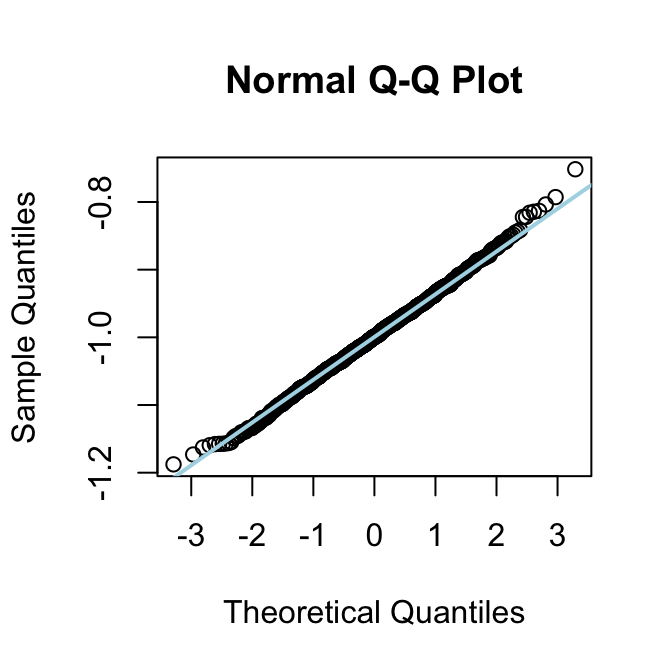

## Simulation - Non-finite variance

```r
set.seed(1289)
Nsim <- 1000
beta_hat_2 <- vector("numeric", Nsim)
for (i in 1:Nsim) {
  ## error
  eps <- rt(n, 1)
  ## Sim
  y_sim <- beta_0 + beta_1 * x_1 + beta_2 * x_2 + eps
  ## Fit
  fit <- lm(y_sim ~ x_1 + x_2)
  ## Get beta_2
  beta_hat_2[i] <- coef(fit)[3]
}
```

## Simulation - Non-finite variance

```r
## Empirical distribution
qqnorm(beta_hat_2); qqline(beta_hat_2, col = "lightblue", lwd = 2)
```

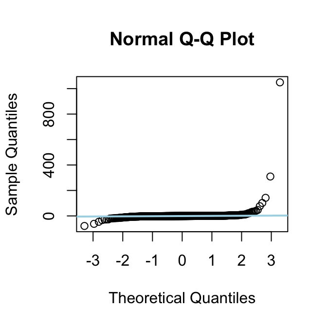

## Simulation - Not Gaussian

- If $\epsilon$ has **finite** variance:
  - The coefficients will be *approximately* Gaussian (empirically).
  - The confidence intervals **won’t be exact**.
  - CI tend to be **too narrow** (for a heavy tail distribution).
- If $\epsilon$ has **non-finite** variance:
  - The Gaussian approximation for the coefficients becomes bad.
  - CIs won’t be good.
  - Extra care must be taken (robust regression).
  - Ex for $\epsilon$: Student with $1$ or $2$ df, Cauchy,

# Homoscedasticity

## Homoscedasticity

- No rigorous test
- Useful to plot $t^*_i$ against $\hat{y}_i$
- Detect increasing variance, or changing expectation

## Increasing variance - Simulation

```r
set.seed(1289)

## Predictors
n <- 200
x_1 <- sort(runif(n, min = 0, max = 2))
x_2 <- sort(runif(n, min = 0, max = 2))

## Model
beta_0 <- 1; beta_1 <- 3; beta_2 <- 1

## sim
sd_het <- abs(rnorm(n, sqrt(1:n)/2, 0.1))
eps <- rnorm(n, mean = 0, sd = sd_het)
y_sim <- beta_0 + beta_1 * x_1 + beta_2 * x_2 + eps

## Fit
fit <- lm(y_sim ~ x_1 + x_2)
```

## Increasing variance - Student residuals

```r
## Studentized residuals vs pred
plot(predict(fit), rstudent(fit),
     xlab = expression(hat(y)[i]), ylab = expression(paste(t[i],"*")))
```

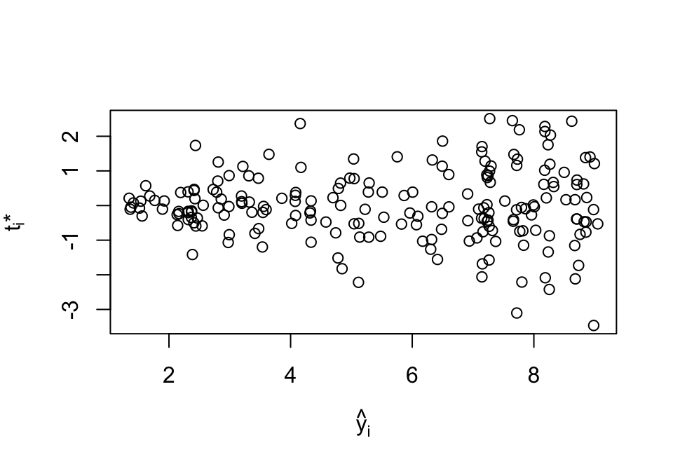

## Increasing variance - Student residuals

```r
## Abs Studentized residuals vs pred
plot(predict(fit), abs(rstudent(fit)),
     xlab = expression(hat(y)[i]),
     ylab = expression(abs(paste(t[i],"*"))))
lines(lowess(predict(fit), abs(rstudent(fit))), col = "firebrick")
```

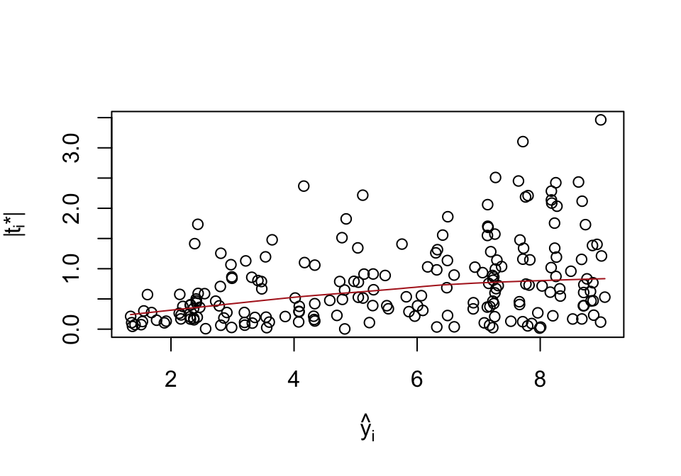

## Increasing variance - Weighting

Weight observations:

```r
## Weighting
y_weight <- y_sim / sqrt(1:n)

## Fit
fit <- lm(y_weight ~ x_1 + x_2)
```

## Increasing variance - Weighting

```r
## Studentized residuals vs pred
plot(predict(fit), rstudent(fit),
     xlab = expression(hat(y)[i]), ylab = expression(t[i]^"*"))
```

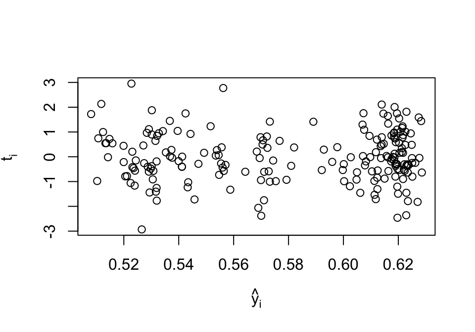

## Increasing variance - Weighting

```r
## Abs Studentized residuals vs pred
plot(predict(fit), abs(rstudent(fit)),
     xlab = expression(hat(y)[i]),
     ylab = expression(abs(paste(t[i],"*"))))
lines(lowess(predict(fit), abs(rstudent(fit))), col = "firebrick")
```

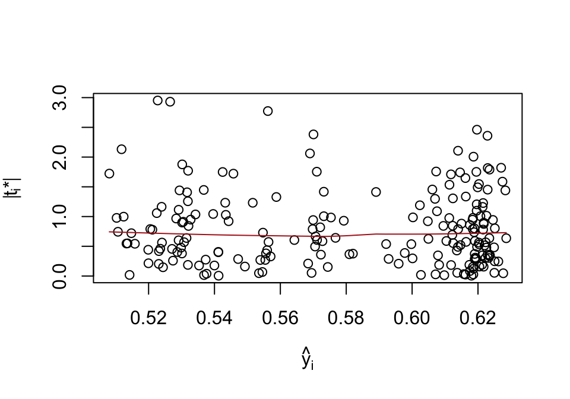

# Structure

## Structure

- Spacial or temporal structure
- “Forgotten” predictor
- No rigorous test or method

## Structure - Simulation

```r
set.seed(1289)

## Predictors
n <- 200
x_1 <- sort(runif(n, min = 0, max = 2))
x_2 <- sin(sort(3 * runif(n, min = 0, max = 2)))

## sim
eps <- rnorm(n, mean = 0, sd = 0.2)
y_sim <- 1 + 2 * x_1 +  0.5 * x_2 + eps

## Fit
fit <- lm(y_sim ~ x_1)
```

## Structure - Studentized residuals

```r
## Studentized residuals vs pred
plot(predict(fit), rstudent(fit),
     xlab = expression(hat(y)[i]), ylab = expression(paste(t[i],"*")))
lines(lowess(predict(fit), rstudent(fit)), col = "firebrick")
```

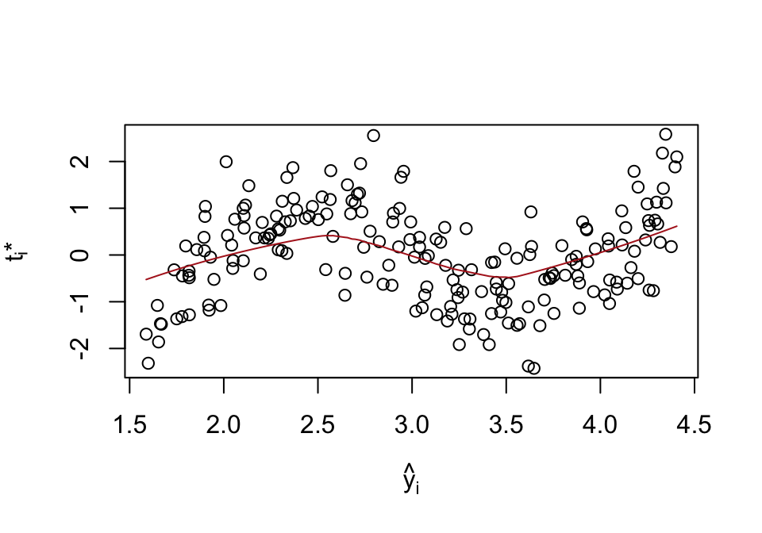

## Structure - Studentized residuals

```r
## Fit
fit <- lm(y_sim ~ x_1 + x_2)

## Studentized residuals vs pred
plot(predict(fit), rstudent(fit),
     xlab = expression(hat(y)[i]), ylab = expression(paste(t[i],"*")))
lines(lowess(predict(fit), rstudent(fit)), col = "firebrick")
```

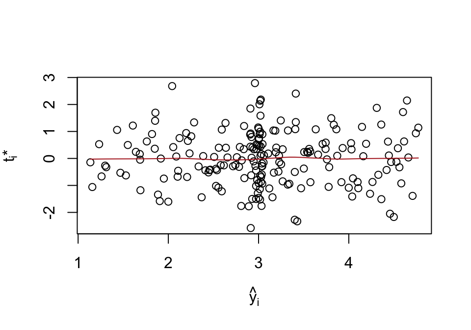

# Advertising data

## Advertising data - Fit

```r
## Advertising data
library(here)
ad <- read.csv(here("data", "Advertising.csv"), row.names = "X")

## linear model
fit <- lm(sales ~ TV + radio, data = ad)
```

## Advertising data - Plots

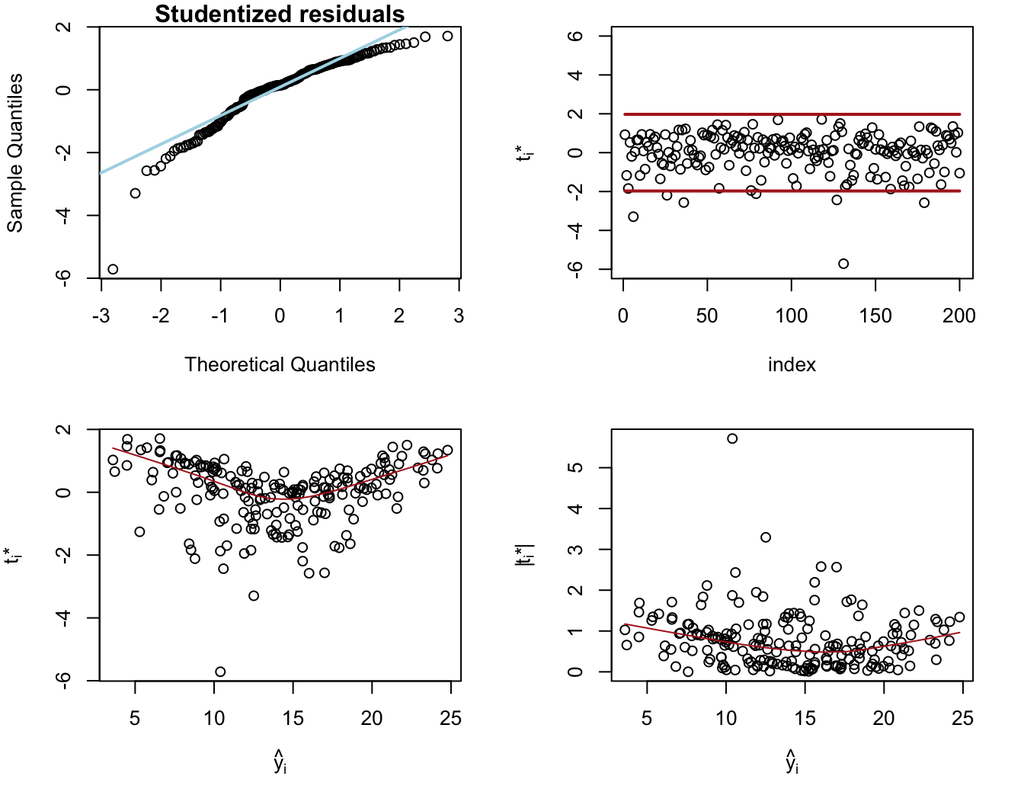

## Transform the data

What if `sales` depends on $f$(`TV`) instead of just `TV`, with $f$ known ?

I.e. take *non-linear* effects into account.

E.g. $f(\cdot)$ is $\sqrt{\cdot}$, $\log(\cdot)$, …

No rigourous way to find $f$ (in this class).

Look at the data.

## Advertising data - Plots

```r
attach(ad)
par(mfrow = c(1, 2))
plot(TV, sales); plot(sqrt(TV), sales);
```

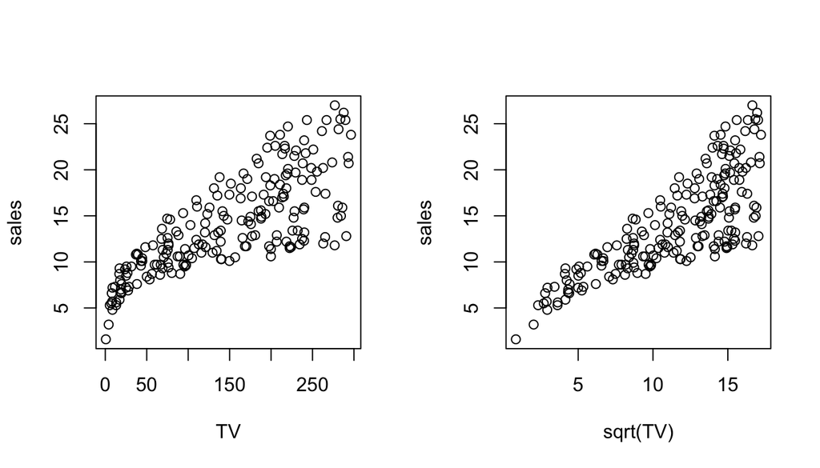

## Advertising data - Fit - Transform

```r
## linear model
fit <- lm(sales ~ sqrt(TV) + radio, data = ad)
```

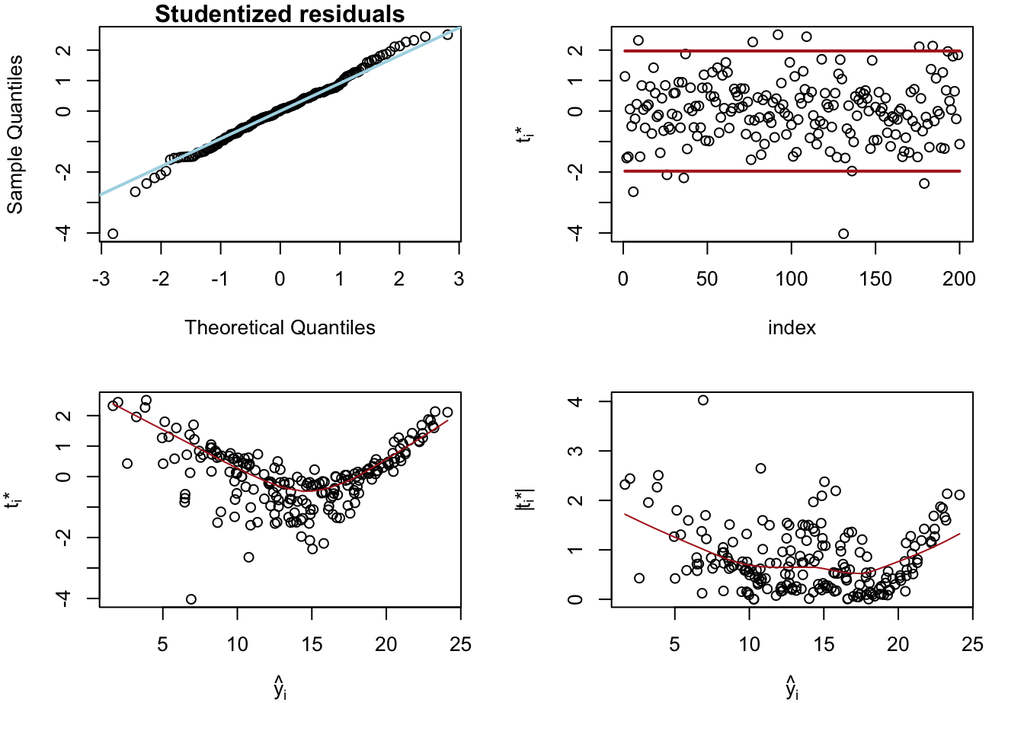

## Interacting effects

What if `TV` and `radio` are not independent ?

I.e. are there *synergy* effects ?

If I spend some money on `radio`, is it increasing the effect of `TV`?

If I have $100\$$, is it better to spend all on either `TV` or `radio`, or $50\$$ on each ?

## Interacting effects

We can fit the model:
$$\texttt{sales} = \beta_0 + \beta_1 \texttt{TV} + \beta_2 \texttt{radio} + \beta_3 \texttt{TV} \times \texttt{radio} + \epsilon$$

i.e
$$\texttt{sales} = \beta_0 + (\beta_1 + \beta_3 \texttt{radio}) \texttt{TV} + \beta_2 \texttt{radio} + \epsilon$$

$\beta_3$: increase in the effectiveness of `TV` advertising for a one unit increase in `radio` advertising (or vice-versa)

## Advertising data - Fit - Interactions

```r
## linear model
fit <- lm(sales ~ sqrt(TV) + radio + radio * sqrt(TV), data = ad)
```

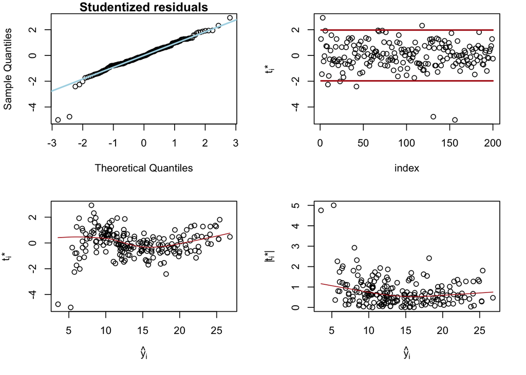

## Advertising data - Fit - Interactions

```r
summary(fit)
```

```
Call:
lm(formula = sales ~ sqrt(TV) + radio + radio * sqrt(TV), data = ad)

Residuals:
    Min      1Q  Median      3Q     Max
-2.0562 -0.2757 -0.0121  0.2758  1.2421

Coefficients:
                 Estimate Std. Error t value Pr(>|t|)
(Intercept)     4.4444112  0.1793714  24.778  < 2e-16 ***
sqrt(TV)        0.4383960  0.0150223  29.183  < 2e-16 ***
radio          -0.0500957  0.0062645  -7.997 1.09e-13 ***
sqrt(TV):radio  0.0215106  0.0005179  41.538  < 2e-16 ***
---
Signif. codes:  0 '***' 0.001 '**' 0.01 '*' 0.05 '.' 0.1 ' ' 1

Residual standard error: 0.4476 on 196 degrees of freedom
Multiple R-squared:  0.9928,    Adjusted R-squared:  0.9926
F-statistic:  8949 on 3 and 196 DF,  p-value: < 2.2e-16
```

# Outliers and Leverage

## Outliers and Leverage

**Question**: Are my estimates *robust* ?

i.e. if I remove one observation, do they change a lot ?

e.g. Outliers can have a strong leverage.

## Outliers and Leverage - Simulation

```r
set.seed(1289)

## sim
n <- 20
x_1 <- runif(n-1, min = -2, max = 2)
eps <- rnorm(n-1, mean = 0, sd = 1)
y_sim <- 1 - 2 * x_1 + eps

## Outlier
x_1[n] <- 4
y_sim[n] <- 10 * max(y_sim)
```

## Outliers and Leverage - Simulation

```r
## Plot
plot(x_1, y_sim)
abline(a = 1, b = -2, col = "firebrick", lwd = 2)
```

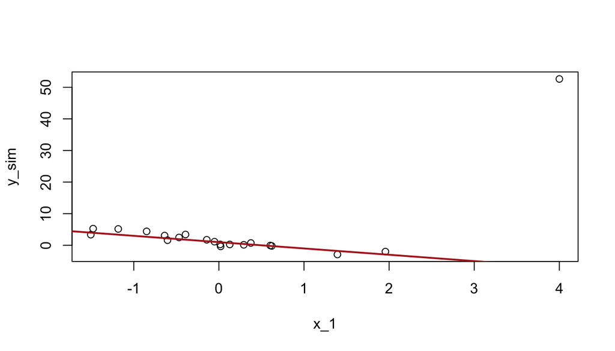

## Outliers and Leverage - Simulation

```r
## Fit
fit <- lm(y_sim ~ x_1)
summary(fit)
```

```
Call:
lm(formula = y_sim ~ x_1)

Residuals:
    Min      1Q  Median      3Q     Max
-16.155  -4.801  -1.460   3.757  27.280

Coefficients:
            Estimate Std. Error t value Pr(>|t|)
(Intercept)    3.431      2.163   1.586  0.13017
x_1            5.480      1.752   3.128  0.00581 **
---
Signif. codes:  0 '***' 0.001 '**' 0.01 '*' 0.05 '.' 0.1 ' ' 1

Residual standard error: 9.639 on 18 degrees of freedom
Multiple R-squared:  0.3522,    Adjusted R-squared:  0.3162
F-statistic: 9.787 on 1 and 18 DF,  p-value: 0.005806
```

## Outliers and Leverage - Simulation

```r
## Plot
plot(x_1, y_sim)
abline(a = 1, b = -2, col = "firebrick", lwd = 2) ## True
abline(reg = fit, col = "lightblue", lwd = 2) ## Fitted
```

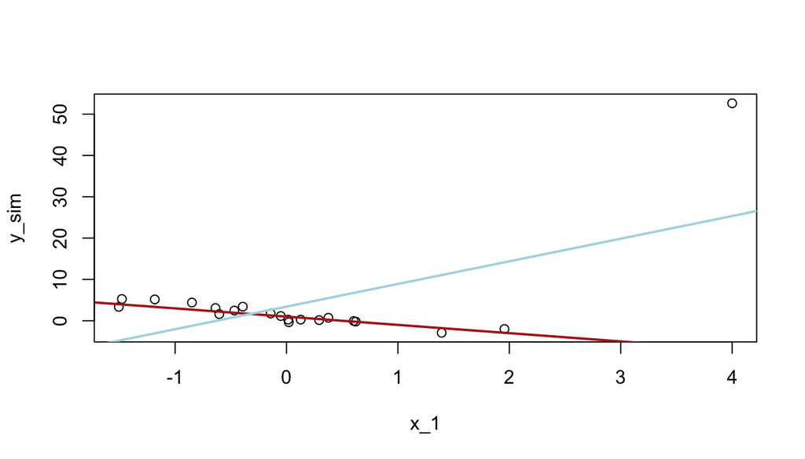

## Outliers and Leverage - Simulation

```r
## Fit without outlier
fit_no <- lm(y_sim[-n] ~ x_1[-n])
summary(fit_no)
```

```
Call:
lm(formula = y_sim[-n] ~ x_1[-n])

Residuals:
    Min      1Q  Median      3Q     Max
-1.5245 -0.7559  0.1282  0.4912  1.3617

Coefficients:
            Estimate Std. Error t value Pr(>|t|)
(Intercept)   1.2107     0.2133   5.677 2.73e-05 ***
x_1[-n]      -2.3386     0.2442  -9.578 2.90e-08 ***
---
Signif. codes:  0 '***' 0.001 '**' 0.01 '*' 0.05 '.' 0.1 ' ' 1

Residual standard error: 0.9235 on 17 degrees of freedom
Multiple R-squared:  0.8437,    Adjusted R-squared:  0.8345
F-statistic: 91.73 on 1 and 17 DF,  p-value: 2.903e-08
```

## Outliers and Leverage - Simulation

```r
## Plot
plot(x_1, y_sim)
abline(a = 1, b = -2, col = "firebrick", lwd = 2) ## True
abline(reg = fit, col = "lightblue", lwd = 2) ## Fitted
abline(reg = fit_no, col = "darkgreen", lwd = 2) ## Fitted - no outlier
```

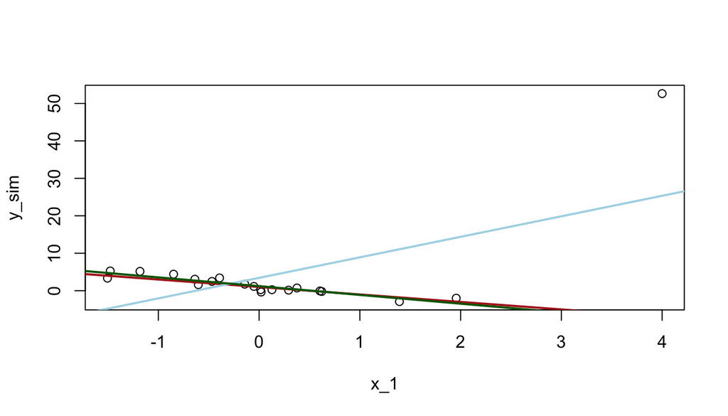

## Outliers and Leverage

Removing one point has a dramatic effect.

Can we compute a *weight* for the importance of one observation?

Look at the **projection** matrix $\to$ **leverage**.

# Orthogonal Projection Matrix

## Orthogonal Projection Matrix

The prevision is computed from:
$$\hat{\mathbf{y}} = \mathbf{H} \mathbf{y}$$
with
$$\mathbf{H}
= \mathbf{P}^{\mathbf{X}}
= \mathbf{X}(\mathbf{X}^{T}\mathbf{X})^{-1}\mathbf{X}^{T}$$

i.e.
$$\hat{y}_i
= \sum_{j = 1}^n h_{ij} y_j
= h_{ii}y_i + \sum_{j\neq i} h_{ij} y_j$$

$h_{ii}$ gives the “weight” of each observation on its own prevision.

Properties of $\mathbf{H}$ ?

## Properties of $\mathbf{H}$

$$\mathbf{H}
= \mathbf{P}^{\mathbf{X}}
= \mathbf{X}(\mathbf{X}^{T}\mathbf{X})^{-1}\mathbf{X}^{T}$$

We have:

1. $\text{tr}(\mathbf{H}) = \sum_{i = 1}^n h_{ii} = p$.
2. $\sum_{i = 1}^n\sum_{j = 1}^n h_{ij}^2 = p$.
3. $0 \leq h_{ii} \leq 1$ for all $i \in \{1, \dotsc, n\}$.
4. If $h_{ii} = 0$ or $h_{ii} = 1$, then $h_{ij} = 0$ for all $j \neq i$.
5. $-0.5 \leq h_{ij} \leq 0.5$ for all $i \neq j$.

**Reminder**:
$$\mathbf{H} = \mathbf{H}^2
\quad
\text{and}
\quad
\mathbf{H}^T = \mathbf{H}$$

## Properties of $\mathbf{H}$ - Proof - 1/4

1-
$$\text{tr}(\mathbf{H}) = \text{rg}(\mathbf{X}) = p$$

2-
$$p = \text{tr}(\mathbf{H})
= \text{tr}(\mathbf{H}^2)
= \text{tr}(\mathbf{H}^T\mathbf{H})
= \sum_{i = 1}^n\sum_{j = 1}^n h_{ij}^2$$

## Properties of $\mathbf{H}$ - Proof - 2/4

3-
$$\mathbf{H}_{ii} = (\mathbf{H}^2)_{ii}$$

hence:
$$h_{ii}
= \sum_{j = 1}^n h_{ij}h_{ji}
= \sum_{j = 1}^n h_{ij}^2
= h_{ii}^2 + \sum_{j \neq i} h_{ij}^2$$

$$h_{ii}(1 - h_{ii})
= \sum_{j \neq i} h_{ij}^2
\geq 0$$

and
$$0 \leq h_{ii} \leq 1$$

## Properties of $\mathbf{H}$ - Proof - 3/4

4-
$$h_{ii}(1 - h_{ii})
= \sum_{j \neq i} h_{ij}^2$$

If $h_{ii} = 0$ or $h_{ii} = 1$, then $h_{ij} = 0$ for all $j \neq i$.

## Properties of $\mathbf{H}$ - Proof - 4/4

5-
$$h_{ii}(1 - h_{ii})
= h_{ij}^2 + \sum_{k \neq i,j} h_{ik}^2$$

$h_{ii}(1 - h_{ii})$ is maximal in $h_{ii} = 0.5$, so:
$$0 \leq
h_{ij}^2 + \sum_{k \neq i,j} h_{ik}^2
\leq 0.25$$
$$0 \leq
h_{ij}^2
\leq 0.25$$
and:
$$-0.5 \leq
h_{ij}
\leq 0.5$$

## Leverage

$$\hat{y}_i
= \sum_{j = 1}^n h_{ij} y_j
= h_{ii}y_i + \sum_{j\neq i} h_{ij} y_j$$

- If $h_{ii} = 1$, then $h_{ij} = 0$ for all $j \neq i$, and $\hat{y}_i = h_{ii}y_i$  
  $\to$ $\hat{y}_i$ is completely determined by $y_i$.
- If $h_{ii} = 0$, then $h_{ij} = 0$ for all $j \neq i$, and $\hat{y}_i = 0$  
  $\to$ $y_i$ does not have any effect on $\hat{y}_i$.
- If $h_{ii}$ is *“large”*  
  $\to$ $y_i$ has a strong impact on $\hat{y}_i$.
- What is *“large”* ?

## Leverage

As $\text{tr}(\mathbf{H}) = \text{rg}(\mathbf{X}) = p$, if the $h_{ii}$ are perfectly ballanced, (all equal to $h$), then $h = p/n$.

**Leverage Point** $i$ is a leverage point if:

- $h_{ii} > 2p/n$ *[Hoaglin & Welsch, 1978]*
- $h_{ii} > 3p/n$, $p > 6$ et $n − p > 12$ *[Velleman & Welsch, 1981]*
- $h_{ii} > 0.5$ *[Huber, 1981]*

## Leverage - Simulation

```r
## Plot
plot(x_1, y_sim)
abline(a = 1, b = -2, col = "firebrick", lwd = 2) ## True
abline(reg = fit, col = "lightblue", lwd = 2) ## Fitted
abline(reg = fit_no, col = "darkgreen", lwd = 2) ## Fitted - no outlier
```

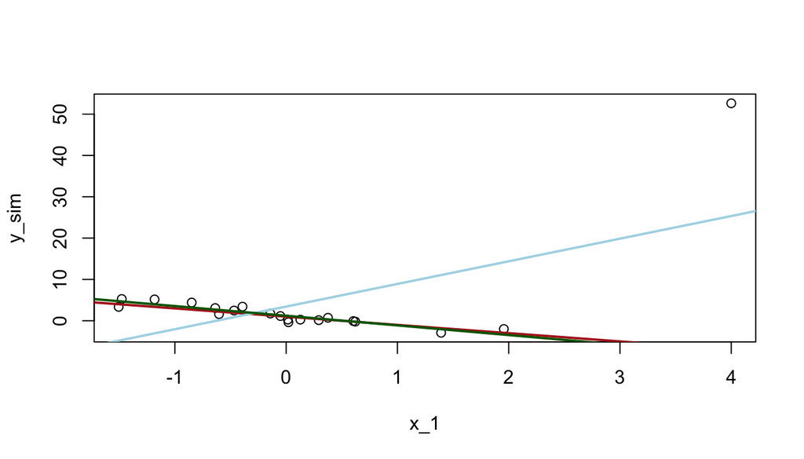

## Leverage - Simulation

```r
## Leverage
h_val <- hatvalues(fit)
## Plot
barplot(h_val)
abline(h = 2 * 2 / n, lty = 2)
abline(h = 3 * 2 / n, lty = 3)
```

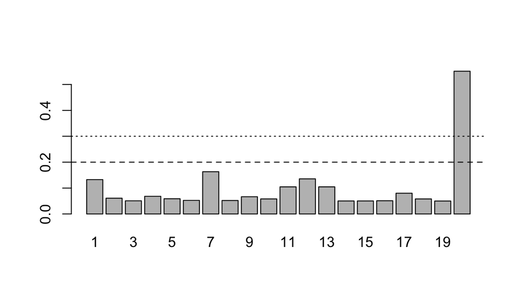

## Leverage - Simulation - bis

```r
set.seed(1289)

## sim
n <- 20
x_1 <- runif(n-1, min = -2, max = 2)
eps <- rnorm(n-1, mean = 0, sd = 1)
y_sim <- 1 - 2 * x_1 + eps

## (Not an) Outlier
x_1[n] <- 4
y_sim[n] <- 1 - 2 * x_1[n]
```

## Leverage - Simulation - bis

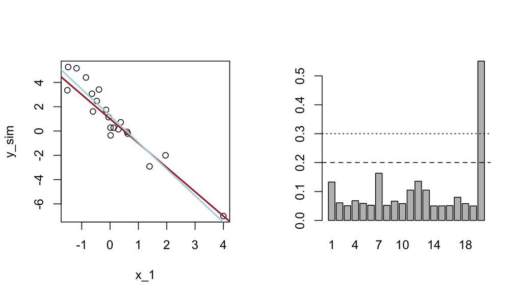

Last point is consistent with the other observations.

But its $x$ value is high $\to$ high leverage point.

## Outlier vs High Leverage

- **Outlier**:  
  Very different from other points ($y$).  
  Not necessarily high leverage.  
  $~$

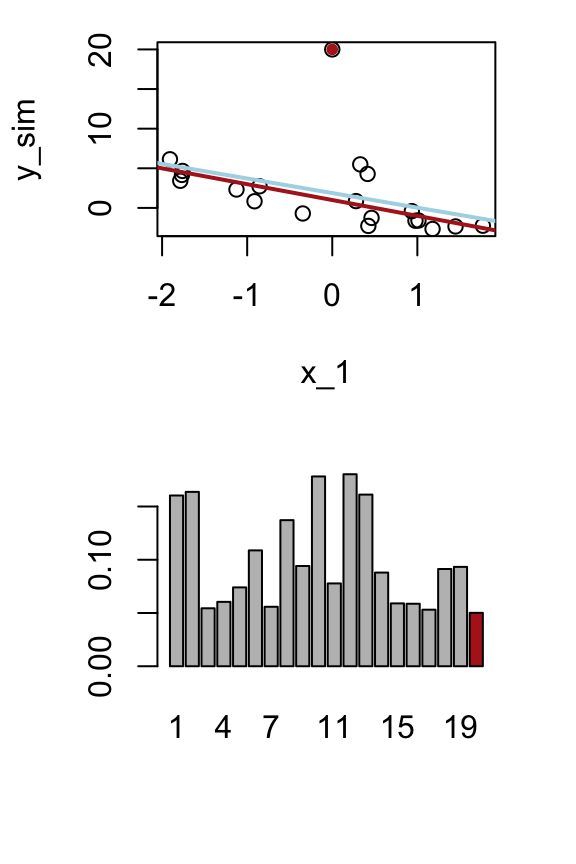

- **High leverage point**:  
  Strong impact on the estimation  
  Very different predictor ($x$).  
  Not necessarily an outlier.

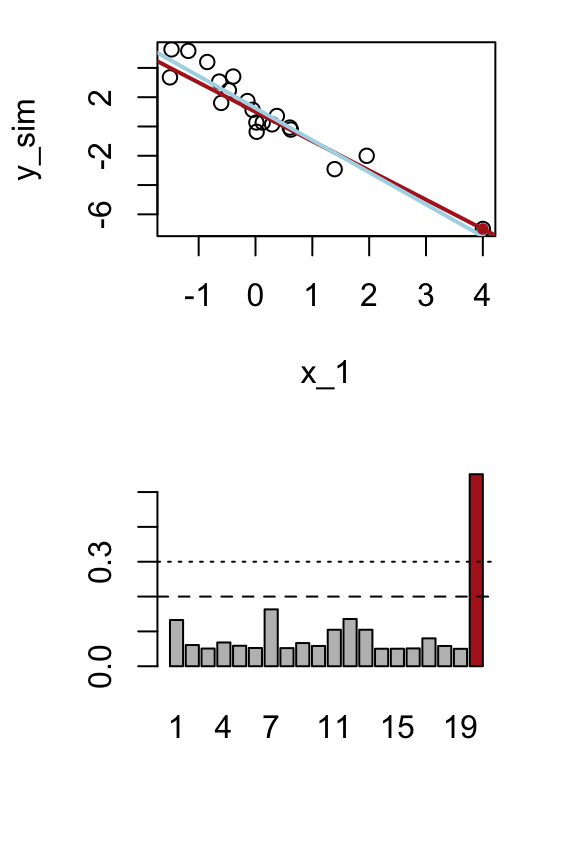

# Cook Distance

## Outlier vs Hight Leverage

- **Outlier**:
  - Very different from other points ($y$).
  - Not necessarily high leverage.
- **High leverage point**:
  - Strong impact on the estimation
  - Very different predictor ($x$).
  - Effect of $y_i$ on $\hat{y}_i$.
  - Not necessarily an outlier.
- **Cook Distance**:
  - “Compromise” between outliers and high leverage points.
  - Effect of $y_i$ on $\hat{\boldsymbol{\beta}}$ directly.

## Cook Distance

**Recall**:
$$\frac{1}{p\hat{\sigma}^2}\left(\hat{\boldsymbol{\beta}} - \boldsymbol{\beta}\right)^T (\mathbf{X}^T\mathbf{X})\left(\hat{\boldsymbol{\beta}} - \boldsymbol{\beta}\right)
\sim
\mathcal{F}^p_{n-p}$$

**Confidence Region**: with a probability of $1-\alpha$:
$$\frac{1}{p\hat{\sigma}^2}\left(\hat{\boldsymbol{\beta}} - \boldsymbol{\beta}\right)^T (\mathbf{X}^T\mathbf{X})\left(\hat{\boldsymbol{\beta}} - \boldsymbol{\beta}\right)
\leq
f^p_{n-p}(1 - \alpha)$$

**Cook Distance**:
$$C_i =
\frac{1}{p\hat{\sigma}^2}
\left(\hat{\boldsymbol{\beta}}_{(-i)} - \hat{\boldsymbol{\beta}}\right)^T (\mathbf{X}^T\mathbf{X})
\left(\hat{\boldsymbol{\beta}}_{(-i)} - \hat{\boldsymbol{\beta}}\right)$$

## Cross Validation

**Leave-one-out** cross validation: for all $i$

1. Remove observation $i$ from the dataset:
   - $\mathbf{y}_{(-i)} = (y_1, \dotsc, y_{i-1}, y_{i+1}, \dotsc, y_n)^T$ (remove obs $i$)
   - $\mathbf{X}_{(-i)} = (\mathbf{x}^1, \dotsc, \mathbf{x}^{i-1}, \mathbf{x}^{i+1}, \dotsc, \mathbf{x}^n)^T$ (remove line $i$)
2. Fit the dataset *without observation $i$*.
   - Get $\hat{\boldsymbol{\beta}}_{(-i)}$ and $\hat{\sigma}^2_{(-i)}$ using $\mathbf{y}_{(-i)}$ and $\mathbf{X}_{(-i)}$.
3. Predict point $i$ using fitted values
   - $\hat{y}_i^P = \mathbf{x}^i\hat{\boldsymbol{\beta}}_{(-i)}$

## Cook Distance

**Cook Distance**:
$$C_i =
\frac{1}{p\hat{\sigma}^2}
\left(\hat{\boldsymbol{\beta}}_{(-i)} - \hat{\boldsymbol{\beta}}\right)^T (\mathbf{X}^T\mathbf{X})
\left(\hat{\boldsymbol{\beta}}_{(-i)} - \hat{\boldsymbol{\beta}}\right)$$

We have:
$$C_i
= \frac{h_{ii}(y_{i} - \hat{y}_{i}^P)^2}{p\hat{\sigma}^2}
= \frac{h_{ii}}{p(1-h_{ii})^2}\frac{\hat{\epsilon}_i^2}{\hat{\sigma}^2}
= \frac{h_{ii}}{p(1-h_{ii})}t_i^2$$

**Note**:  
Cook “distance” is actually the square of a distance.

## Cook Distance - Proof

$$C_i
= \frac{h_{ii}(y_{i} - \hat{y}_{i}^P)^2}{p\hat{\sigma}^2}
= \frac{h_{ii}}{p(1-h_{ii})^2}\frac{\hat{\epsilon}_i^2}{\hat{\sigma}^2}
= \frac{h_{ii}}{p(1-h_{ii})}t_i^2$$

**Hints**:

$$(\mathbf{A} + \mathbf{u}\mathbf{v}^T)^{-1}
=
\mathbf{A}^{-1}
-
\frac{
\mathbf{A}^{-1} \mathbf{u}\mathbf{v}^T \mathbf{A}^{-1}
}{
1 + \mathbf{v}^T\mathbf{A}^{-1}\mathbf{u}
}.$$

$$\mathbf{X}^T\mathbf{X}
= \mathbf{X}_{(-i)}^T\mathbf{X}_{(-i)} + (\mathbf{x}^{i})^T\mathbf{x}^i$$

$$\mathbf{X}^T\mathbf{y}
= \mathbf{X}_{(-i)}^T\mathbf{y}_{(-i)} + (\mathbf{x}^{i})^Ty_i$$

$$h_{ii}
=
[\mathbf{X}(\mathbf{X}^{T}\mathbf{X})^{-1}\mathbf{X}^{T}]_{ii}
= \mathbf{x}^{i} (\mathbf{X}^T\mathbf{X})^{-1} (\mathbf{x}^{i})^T$$

So:
$$(\mathbf{X}_{(-i)}^T\mathbf{X}_{(-i)})^{-1}
= (\mathbf{X}^T\mathbf{X} - (\mathbf{x}^{i})^T\mathbf{x}^i)^{-1}
= \cdots$$

$$\hat{\boldsymbol{\beta}}_{(-i)}
= (\mathbf{X}_{(-i)}^T\mathbf{X}_{(-i)})^{-1}\mathbf{X}_{(-i)}^T\mathbf{y}_{(-i)}
= \cdots$$

## Cook Distance - Proof - 1/6

$$(\mathbf{X}_{(-i)}^T\mathbf{X}_{(-i)})^{-1}
= (\mathbf{X}^T\mathbf{X} - (\mathbf{x}^{i})^T\mathbf{x}^i)^{-1}
= \cdots$$

$$(\mathbf{X}_{(-i)}^T\mathbf{X}_{(-i)})^{-1}
= (\mathbf{X}^T\mathbf{X})^{-1}
+
\frac{
(\mathbf{X}^T\mathbf{X})^{-1} (\mathbf{x}^{i})^T\mathbf{x}^{i} (\mathbf{X}^T\mathbf{X})^{-1}
}{
1 - \mathbf{x}^{i}(\mathbf{X}^T\mathbf{X})^{-1}(\mathbf{x}^{i})^T
}$$

$$(\mathbf{X}_{(-i)}^T\mathbf{X}_{(-i)})^{-1}
= (\mathbf{X}^T\mathbf{X})^{-1} + \frac{(\mathbf{X}^T\mathbf{X})^{-1} (\mathbf{x}^{i})^T\mathbf{x}^{i} (\mathbf{X}^T\mathbf{X})^{-1}}{1 - h_{ii}}$$

## Cook Distance - Proof - 2/6

$$\hat{\boldsymbol{\beta}}_{(-i)}
= (\mathbf{X}_{(-i)}^T\mathbf{X}_{(-i)})^{-1}\mathbf{X}_{(-i)}^T\mathbf{y}_{(-i)}$$

But:
$$(\mathbf{X}_{(-i)}^T\mathbf{X}_{(-i)})^{-1}
=
(\mathbf{X}^T\mathbf{X})^{-1} +
\frac{(\mathbf{X}^T\mathbf{X})^{-1} (\mathbf{x}^{i})^T\mathbf{x}^{i} (\mathbf{X}^T\mathbf{X})^{-1}}{1 - h_{ii}}$$
$$\mathbf{X}_{(-i)}^T\mathbf{y}_{(-i)}
=
\mathbf{X}^T\mathbf{y} - (\mathbf{x}^{i})^Ty_i$$

Hence:
$$\begin{multline}
\hat{\boldsymbol{\beta}}_{(-i)}
= \left[
(\mathbf{X}^T\mathbf{X})^{-1} + \frac{(\mathbf{X}^T\mathbf{X})^{-1} (\mathbf{x}^{i})^T\mathbf{x}^{i} (\mathbf{X}^T\mathbf{X})^{-1}}{1 - h_{ii}}
\right]
\\
\times
[\mathbf{X}^T\mathbf{y} - (\mathbf{x}^{i})^Ty_i]
\end{multline}$$

## Cook Distance - Proof - 3/6

$$\begin{multline}
\hat{\boldsymbol{\beta}}_{(-i)}
= (\mathbf{X}^T\mathbf{X})^{-1} \mathbf{X}^T\mathbf{y}
- (\mathbf{X}^T\mathbf{X})^{-1} (\mathbf{x}^{i})^Ty_i
\\
+ \frac{(\mathbf{X}^T\mathbf{X})^{-1} (\mathbf{x}^{i})^T}{1 - h_{ii}}\mathbf{x}^{i} (\mathbf{X}^T\mathbf{X})^{-1} \mathbf{X}^T\mathbf{y}
\\
- \frac{(\mathbf{X}^T\mathbf{X})^{-1} (\mathbf{x}^{i})^T\mathbf{x}^{i} (\mathbf{X}^T\mathbf{X})^{-1}(\mathbf{x}^{i})^T}{1 - h_{ii}} y_i
\end{multline}$$

$$\begin{multline}
\hat{\boldsymbol{\beta}}_{(-i)}
= \hat{\boldsymbol{\beta}}
- (\mathbf{X}^T\mathbf{X})^{-1} (\mathbf{x}^{i})^Ty_i
+ \frac{1}{1-h_{ii}}(\mathbf{X}^T\mathbf{X})^{-1} (\mathbf{x}^{i})^T \mathbf{x}^i \hat{\boldsymbol{\beta}}
\\
- \frac{h_{ii}}{1-h_{ii}} (\mathbf{X}^T\mathbf{X})^{-1} (\mathbf{x}^{i})^T y_i
\end{multline}$$

$$\hat{\boldsymbol{\beta}}_{(-i)} - \hat{\boldsymbol{\beta}}
= (\mathbf{X}^T\mathbf{X})^{-1} (\mathbf{x}^{i})^T
\left[\frac{1}{1-h_{ii}} \hat{y}_i
- \left(1 + \frac{h_{ii}}{1-h_{ii}}\right) y_i
\right]$$

## Cook Distance - Proof - 4/6

$$\begin{aligned}
\hat{\boldsymbol{\beta}}_{(-i)} - \hat{\boldsymbol{\beta}}
&= (\mathbf{X}^T\mathbf{X})^{-1} (\mathbf{x}^{i})^T
\frac{1}{1-h_{ii}}
(\hat{y}_i - y_i)\\
&= - (\mathbf{X}^T\mathbf{X})^{-1} (\mathbf{x}^{i})^T
\frac{1}{1-h_{ii}}
\hat{\epsilon}_i
\end{aligned}$$

But remember:
$$y_i - \hat{y}_i^P
= \frac{1}{1-h_{ii}}\hat{\epsilon}_i$$
hence:
$$\hat{\boldsymbol{\beta}}_{(-i)} - \hat{\boldsymbol{\beta}}
= - (y_i - \hat{y}_i^P) (\mathbf{X}^T\mathbf{X})^{-1} (\mathbf{x}^{i})^T$$

## Cook Distance - Proof - 5/6

We have:
$$\hat{\boldsymbol{\beta}}_{(-i)} - \hat{\boldsymbol{\beta}}
= - (y_i - \hat{y}_i^P) (\mathbf{X}^T\mathbf{X})^{-1} (\mathbf{x}^{i})^T$$
$$C_i =
\frac{1}{p\hat{\sigma}^2}
\left(\hat{\boldsymbol{\beta}}_{(-i)} - \hat{\boldsymbol{\beta}}\right)^T (\mathbf{X}^T\mathbf{X})
\left(\hat{\boldsymbol{\beta}}_{(-i)} - \hat{\boldsymbol{\beta}}\right)$$

Hence:
$$\begin{aligned}
C_i
&=
\frac{1}{p\hat{\sigma}^2}
(\mathbf{x}^{i}) (\mathbf{X}^T\mathbf{X})^{-1}
(\mathbf{X}^T\mathbf{X})
(\mathbf{X}^T\mathbf{X})^{-1} (\mathbf{x}^{i})^T
(y_i - \hat{y}_i^P)^2\\
&=
\frac{1}{p\hat{\sigma}^2}
h_{ii}
(y_i - \hat{y}_i^P)^2
\end{aligned}$$

## Cook Distance - Proof - 6/6

$$C_i =
\frac{1}{p\hat{\sigma}^2}
\left(\hat{\boldsymbol{\beta}}_{(-i)} - \hat{\boldsymbol{\beta}}\right)^T (\mathbf{X}^T\mathbf{X})
\left(\hat{\boldsymbol{\beta}}_{(-i)} - \hat{\boldsymbol{\beta}}\right)
=
\frac{1}{p\hat{\sigma}^2}
h_{ii}
(y_i - \hat{y}_i^P)^2$$

and:
$$y_i - \hat{y}_i^P
= \frac{1}{1-h_{ii}}\hat{\epsilon}_i$$

hence:
$$C_i
= \frac{h_{ii}}{p(1-h_{ii})^2}\frac{\hat{\epsilon}_i^2}{\hat{\sigma}^2}
= \frac{h_{ii}}{p(1-h_{ii})}t_i^2$$

## Cook Distance

$$C_i =
\frac{1}{p\hat{\sigma}^2}
\left(\hat{\boldsymbol{\beta}}_{(-i)} - \hat{\boldsymbol{\beta}}\right)^T (\mathbf{X}^T\mathbf{X})
\left(\hat{\boldsymbol{\beta}}_{(-i)} - \hat{\boldsymbol{\beta}}\right)$$

- If $C_i$ is “high”, then the point has a strong influence on the estimation.
- According to *Cook (1977)*:
  - $C_i \leq f^p_{n-p}(0.1)$ : “desirable”
  - $C_i > f^p_{n-p}(0.5) \approx 1$ : “concerning”

## Cook Distance

$$C_i
= \frac{1}{p}\frac{h_{ii}}{(1-h_{ii})}t_i^2$$

- If $C_i$ is “high”, then the point has a strong influence on the estimation.
- $C_i$ is the product of two contributions:
  - $\frac{h_{ii}}{(1-h_{ii})}$ high if $i$ has *high leverage*
  - $t_i^2$ high if $i$ is an *outlier*.

## Cook Distance - Outlier - 1

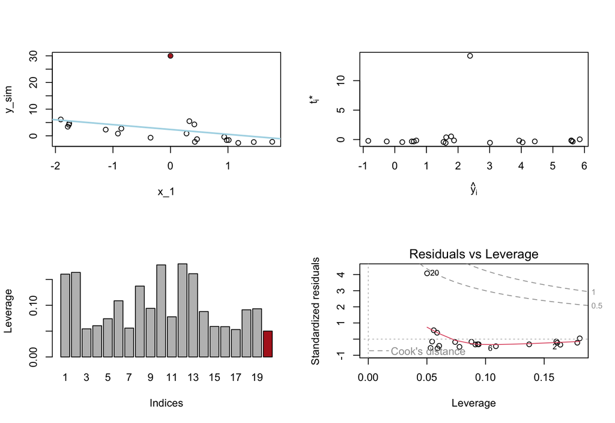

## Cook Distance - Outlier - 2

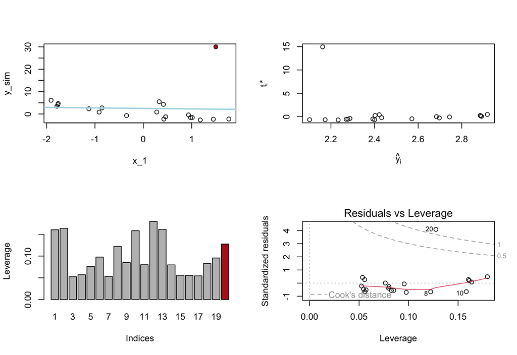

## Cook Distance - High Leverage - 1

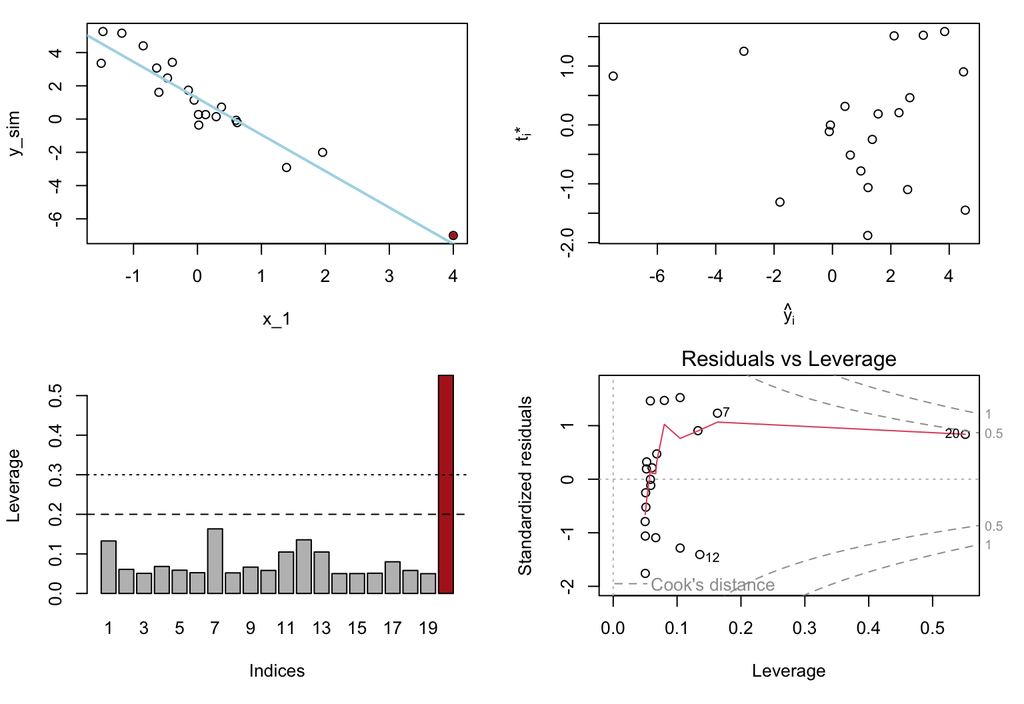

## Cook Distance - High Leverage - 2

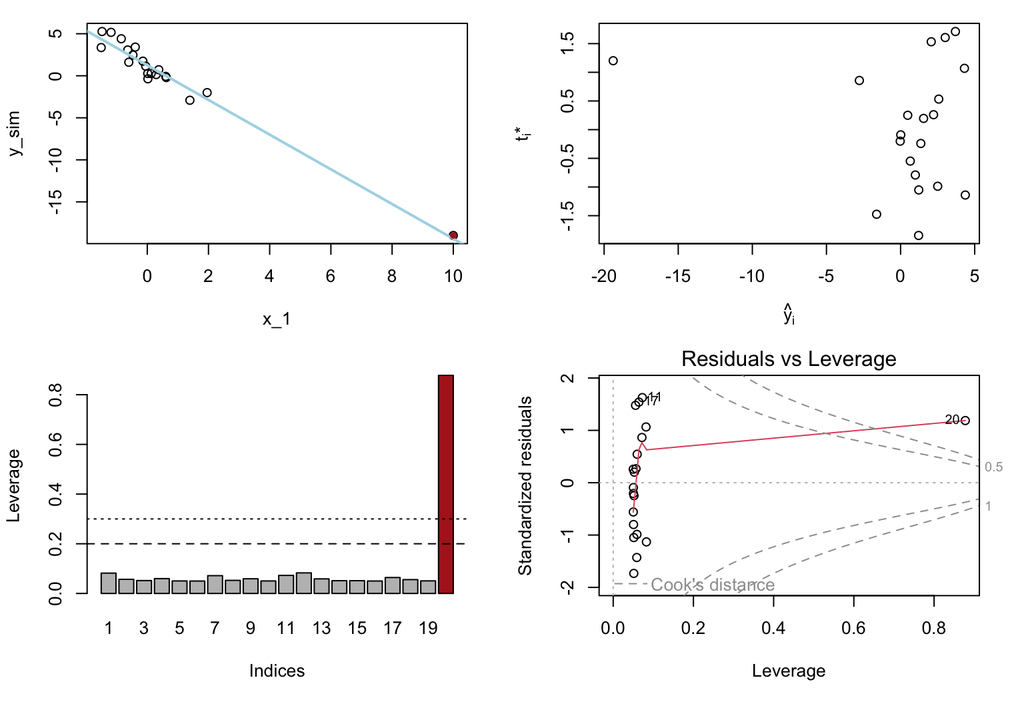